# Risk Factor Analysis

## Outcome Variable

**Outcome Variable:** wast_rec90d

## Predictor Variables

**Intervention Variable:** earlybf

**Adjustment Set:**

- arm
- sex
- W_mage
- meducyrs
- feducyrs
- hhwealth_quart
- hfoodsec
- W_mhtcm
- W_mwtkg
- W_mbmi
- vagbrth
- W_gagebrth
- W_birthwt
- W_birthlen
- W_nrooms
- W_nchldlt5
- brthmon
- W_parity
- impfloor
- impsan
- safeh20
- delta_W_mage
- delta_meducyrs
- delta_feducyrs
- delta_hhwealth_quart
- delta_hfoodsec
- delta_W_mhtcm
- delta_W_mwtkg
- delta_W_mbmi
- delta_vagbrth
- delta_W_gagebrth
- delta_W_birthwt
- delta_W_birthlen
- delta_W_nrooms
- delta_W_nchldlt5
- delta_brthmon
- delta_W_parity
- delta_impfloor
- delta_impsan
- delta_safeh20

## Stratifying Variables

The analysis was stratified on these variable(s):

- agecat
- studyid
- country

## Data Summary

| agecat | studyid | country | earlybf | wast_rec90d | n_cell | n |
| --- | --- | --- | --- | --- | --- | --- |
| 0-24 months | ki0047075b-MAL-ED | BANGLADESH | 1 | 0 | 25 | 122 |
| 0-24 months | ki0047075b-MAL-ED | BANGLADESH | 1 | 1 | 46 | 122 |
| 0-24 months | ki0047075b-MAL-ED | BANGLADESH | 0 | 0 | 18 | 122 |
| 0-24 months | ki0047075b-MAL-ED | BANGLADESH | 0 | 1 | 33 | 122 |
| 0-24 months | ki0047075b-MAL-ED | BRAZIL | 1 | 0 | 3 | 24 |
| 0-24 months | ki0047075b-MAL-ED | BRAZIL | 1 | 1 | 6 | 24 |
| 0-24 months | ki0047075b-MAL-ED | BRAZIL | 0 | 0 | 3 | 24 |
| 0-24 months | ki0047075b-MAL-ED | BRAZIL | 0 | 1 | 12 | 24 |
| 0-24 months | ki0047075b-MAL-ED | INDIA | 1 | 0 | 44 | 181 |
| 0-24 months | ki0047075b-MAL-ED | INDIA | 1 | 1 | 63 | 181 |
| 0-24 months | ki0047075b-MAL-ED | INDIA | 0 | 0 | 27 | 181 |
| 0-24 months | ki0047075b-MAL-ED | INDIA | 0 | 1 | 47 | 181 |
| 0-24 months | ki0047075b-MAL-ED | NEPAL | 1 | 0 | 9 | 98 |
| 0-24 months | ki0047075b-MAL-ED | NEPAL | 1 | 1 | 33 | 98 |
| 0-24 months | ki0047075b-MAL-ED | NEPAL | 0 | 0 | 11 | 98 |
| 0-24 months | ki0047075b-MAL-ED | NEPAL | 0 | 1 | 45 | 98 |
| 0-24 months | ki0047075b-MAL-ED | PERU | 1 | 0 | 5 | 35 |
| 0-24 months | ki0047075b-MAL-ED | PERU | 1 | 1 | 26 | 35 |
| 0-24 months | ki0047075b-MAL-ED | PERU | 0 | 0 | 1 | 35 |
| 0-24 months | ki0047075b-MAL-ED | PERU | 0 | 1 | 3 | 35 |
| 0-24 months | ki0047075b-MAL-ED | SOUTH AFRICA | 1 | 0 | 8 | 84 |
| 0-24 months | ki0047075b-MAL-ED | SOUTH AFRICA | 1 | 1 | 46 | 84 |
| 0-24 months | ki0047075b-MAL-ED | SOUTH AFRICA | 0 | 0 | 7 | 84 |
| 0-24 months | ki0047075b-MAL-ED | SOUTH AFRICA | 0 | 1 | 23 | 84 |
| 0-24 months | ki0047075b-MAL-ED | TANZANIA, UNITED REPUBLIC OF | 1 | 0 | 7 | 51 |
| 0-24 months | ki0047075b-MAL-ED | TANZANIA, UNITED REPUBLIC OF | 1 | 1 | 39 | 51 |
| 0-24 months | ki0047075b-MAL-ED | TANZANIA, UNITED REPUBLIC OF | 0 | 0 | 2 | 51 |
| 0-24 months | ki0047075b-MAL-ED | TANZANIA, UNITED REPUBLIC OF | 0 | 1 | 3 | 51 |
| 0-24 months | ki1000109-EE | PAKISTAN | 1 | 0 | 25 | 314 |
| 0-24 months | ki1000109-EE | PAKISTAN | 1 | 1 | 30 | 314 |

[output cut: 138 more lines]

The following strata were considered:

- agecat: 0-24 months, studyid: ki0047075b-MAL-ED, country: BANGLADESH
- agecat: 0-24 months, studyid: ki0047075b-MAL-ED, country: BRAZIL
- agecat: 0-24 months, studyid: ki0047075b-MAL-ED, country: INDIA
- agecat: 0-24 months, studyid: ki0047075b-MAL-ED, country: NEPAL
- agecat: 0-24 months, studyid: ki0047075b-MAL-ED, country: PERU
- agecat: 0-24 months, studyid: ki0047075b-MAL-ED, country: SOUTH AFRICA
- agecat: 0-24 months, studyid: ki0047075b-MAL-ED, country: TANZANIA, UNITED REPUBLIC OF
- agecat: 0-24 months, studyid: ki1000109-EE, country: PAKISTAN
- agecat: 0-24 months, studyid: ki1000304b-SAS-CompFeed, country: INDIA
- agecat: 0-24 months, studyid: ki1017093c-NIH-Crypto, country: BANGLADESH
- agecat: 0-24 months, studyid: ki1113344-GMS-Nepal, country: NEPAL
- agecat: 0-24 months, studyid: ki1126311-ZVITAMBO, country: ZIMBABWE
- agecat: 0-24 months, studyid: kiGH5241-JiVitA-3, country: BANGLADESH
- agecat: 0-24 months, studyid: kiGH5241-JiVitA-4, country: BANGLADESH
- agecat: 0-6 months, studyid: ki0047075b-MAL-ED, country: BANGLADESH
- agecat: 0-6 months, studyid: ki0047075b-MAL-ED, country: BRAZIL
- agecat: 0-6 months, studyid: ki0047075b-MAL-ED, country: INDIA
- agecat: 0-6 months, studyid: ki0047075b-MAL-ED, country: NEPAL
- agecat: 0-6 months, studyid: ki0047075b-MAL-ED, country: PERU
- agecat: 0-6 months, studyid: ki0047075b-MAL-ED, country: SOUTH AFRICA
- agecat: 0-6 months, studyid: ki0047075b-MAL-ED, country: TANZANIA, UNITED REPUBLIC OF
- agecat: 0-6 months, studyid: ki1000109-EE, country: PAKISTAN
- agecat: 0-6 months, studyid: ki1000304b-SAS-CompFeed, country: INDIA
- agecat: 0-6 months, studyid: ki1017093c-NIH-Crypto, country: BANGLADESH
- agecat: 0-6 months, studyid: ki1113344-GMS-Nepal, country: NEPAL
- agecat: 0-6 months, studyid: ki1126311-ZVITAMBO, country: ZIMBABWE
- agecat: 0-6 months, studyid: kiGH5241-JiVitA-3, country: BANGLADESH
- agecat: 0-6 months, studyid: kiGH5241-JiVitA-4, country: BANGLADESH
- agecat: 6-24 months, studyid: ki0047075b-MAL-ED, country: BANGLADESH
- agecat: 6-24 months, studyid: ki0047075b-MAL-ED, country: BRAZIL
- agecat: 6-24 months, studyid: ki0047075b-MAL-ED, country: INDIA
- agecat: 6-24 months, studyid: ki0047075b-MAL-ED, country: NEPAL
- agecat: 6-24 months, studyid: ki0047075b-MAL-ED, country: PERU
- agecat: 6-24 months, studyid: ki0047075b-MAL-ED, country: SOUTH AFRICA
- agecat: 6-24 months, studyid: ki0047075b-MAL-ED, country: TANZANIA, UNITED REPUBLIC OF
- agecat: 6-24 months, studyid: ki1000109-EE, country: PAKISTAN
- agecat: 6-24 months, studyid: ki1000304b-SAS-CompFeed, country: INDIA
- agecat: 6-24 months, studyid: ki1017093c-NIH-Crypto, country: BANGLADESH
- agecat: 6-24 months, studyid: ki1113344-GMS-Nepal, country: NEPAL
- agecat: 6-24 months, studyid: ki1126311-ZVITAMBO, country: ZIMBABWE
- agecat: 6-24 months, studyid: kiGH5241-JiVitA-3, country: BANGLADESH
- agecat: 6-24 months, studyid: kiGH5241-JiVitA-4, country: BANGLADESH

### Dropped Strata

Some strata were dropped due to rare outcomes:

- agecat: 0-24 months, studyid: ki0047075b-MAL-ED, country: BRAZIL
- agecat: 0-24 months, studyid: ki0047075b-MAL-ED, country: PERU
- agecat: 0-24 months, studyid: ki0047075b-MAL-ED, country: TANZANIA, UNITED REPUBLIC OF
- agecat: 0-6 months, studyid: ki0047075b-MAL-ED, country: BRAZIL
- agecat: 0-6 months, studyid: ki0047075b-MAL-ED, country: NEPAL
- agecat: 0-6 months, studyid: ki0047075b-MAL-ED, country: PERU
- agecat: 0-6 months, studyid: ki0047075b-MAL-ED, country: SOUTH AFRICA
- agecat: 0-6 months, studyid: ki0047075b-MAL-ED, country: TANZANIA, UNITED REPUBLIC OF
- agecat: 6-24 months, studyid: ki0047075b-MAL-ED, country: BRAZIL
- agecat: 6-24 months, studyid: ki0047075b-MAL-ED, country: NEPAL
- agecat: 6-24 months, studyid: ki0047075b-MAL-ED, country: PERU
- agecat: 6-24 months, studyid: ki0047075b-MAL-ED, country: SOUTH AFRICA
- agecat: 6-24 months, studyid: ki0047075b-MAL-ED, country: TANZANIA, UNITED REPUBLIC OF
- agecat: 6-24 months, studyid: ki1017093c-NIH-Crypto, country: BANGLADESH
- agecat: 6-24 months, studyid: kiGH5241-JiVitA-3, country: BANGLADESH

## Methods Detail

We’re interested in the causal parameters $E[Y_a]$ for all values of $a \in \mathcal{A}$. These parameters represent the mean outcome if, possibly contrary to fact, we intervened to set all units to have $A=a$. Under the randomization and positivity assumptions, these are identified by the statistical parameters $\psi_a=E_W[E_{Y|A,W}(Y|A=a,W)]$. In addition, we’re interested in the mean of $Y$, $E[Y]$ under no intervention (the observed mean). We will estimate these parameters by using SuperLearner to fit the relevant likelihood factors – $E_{Y|A,W}(Y|A=a,W)$ and $p(A=a|W)$, and then updating our likelihood fit using a joint TMLE.

For unadjusted analyses ($W=\{\}$), initial likelihoods were estimated using Lrnr_glm to estimate the simple $E(Y|A)$ and Lrnr_mean to estimate $p(A)$. For adjusted analyses, a small library containing Lrnr_glmnet, Lrnr_xgboost, and Lrnr_mean was used.

Having estimated these parameters, we will then use the delta method to estimate relative risks and attributable risks relative to a prespecified baseline level of $A$.

# Results Detail

## Results Plots

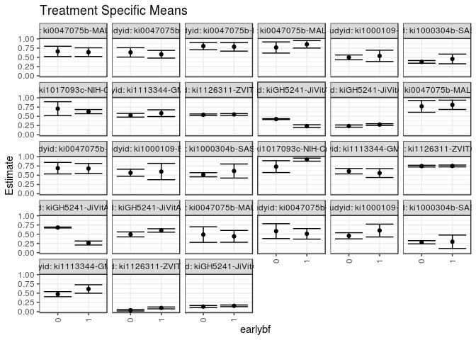

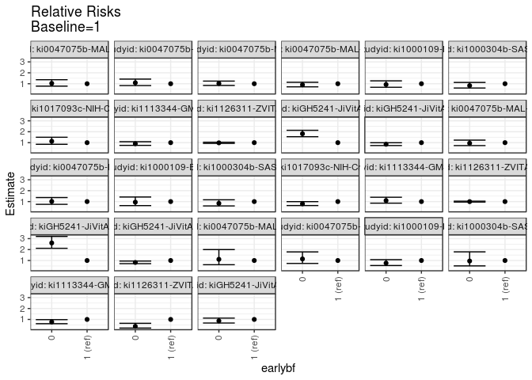

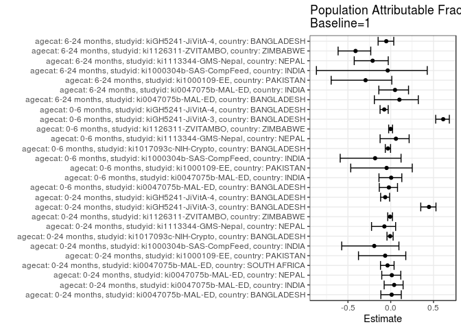

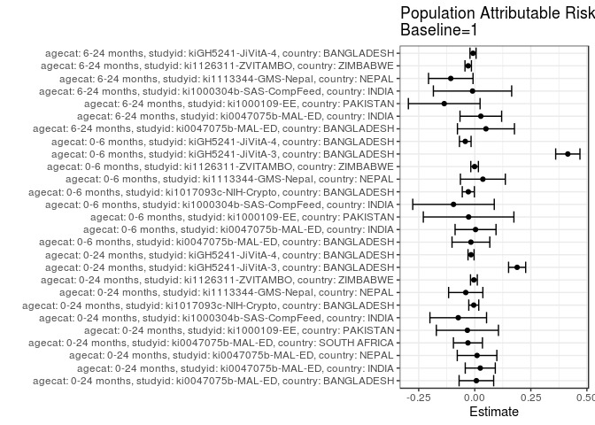

## Results Table

### Parameter: TSM

| agecat | studyid | country | intervention_level | baseline_level | estimate | ci_lower | ci_upper |
| --- | --- | --- | --- | --- | --- | --- | --- |
| 0-24 months | ki0047075b-MAL-ED | BANGLADESH | 1 | NA | 0.6403450 | 0.5230367 | 0.7576533 |
| 0-24 months | ki0047075b-MAL-ED | BANGLADESH | 0 | NA | 0.6608327 | 0.5219675 | 0.7996978 |
| 0-24 months | ki0047075b-MAL-ED | INDIA | 1 | NA | 0.5831829 | 0.4789715 | 0.6873942 |
| 0-24 months | ki0047075b-MAL-ED | INDIA | 0 | NA | 0.6338124 | 0.5071792 | 0.7604456 |
| 0-24 months | ki0047075b-MAL-ED | NEPAL | 1 | NA | 0.7857143 | 0.6676859 | 0.9037426 |
| 0-24 months | ki0047075b-MAL-ED | NEPAL | 0 | NA | 0.8035714 | 0.7055573 | 0.9015856 |
| 0-24 months | ki0047075b-MAL-ED | SOUTH AFRICA | 1 | NA | 0.8518519 | 0.7511196 | 0.9525841 |
| 0-24 months | ki0047075b-MAL-ED | SOUTH AFRICA | 0 | NA | 0.7666667 | 0.6158718 | 0.9174615 |
| 0-24 months | ki1000109-EE | PAKISTAN | 1 | NA | 0.5392762 | 0.3862999 | 0.6922526 |
| 0-24 months | ki1000109-EE | PAKISTAN | 0 | NA | 0.4982145 | 0.4331828 | 0.5632461 |
| 0-24 months | ki1000304b-SAS-CompFeed | INDIA | 1 | NA | 0.4564047 | 0.3249513 | 0.5878581 |
| 0-24 months | ki1000304b-SAS-CompFeed | INDIA | 0 | NA | 0.3767610 | 0.3401947 | 0.4133272 |
| 0-24 months | ki1017093c-NIH-Crypto | BANGLADESH | 1 | NA | 0.6270034 | 0.5706647 | 0.6833421 |
| 0-24 months | ki1017093c-NIH-Crypto | BANGLADESH | 0 | NA | 0.7063359 | 0.5181942 | 0.8944777 |
| 0-24 months | ki1113344-GMS-Nepal | NEPAL | 1 | NA | 0.5832026 | 0.4918285 | 0.6745766 |
| 0-24 months | ki1113344-GMS-Nepal | NEPAL | 0 | NA | 0.5271633 | 0.4762358 | 0.5780908 |
| 0-24 months | ki1126311-ZVITAMBO | ZIMBABWE | 1 | NA | 0.5496239 | 0.5267136 | 0.5725342 |
| 0-24 months | ki1126311-ZVITAMBO | ZIMBABWE | 0 | NA | 0.5404590 | 0.5180063 | 0.5629117 |
| 0-24 months | kiGH5241-JiVitA-3 | BANGLADESH | 1 | NA | 0.2337150 | 0.1963783 | 0.2710517 |
| 0-24 months | kiGH5241-JiVitA-3 | BANGLADESH | 0 | NA | 0.4241107 | 0.4127462 | 0.4354751 |
| 0-24 months | kiGH5241-JiVitA-4 | BANGLADESH | 1 | NA | 0.2752233 | 0.2515701 | 0.2988764 |
| 0-24 months | kiGH5241-JiVitA-4 | BANGLADESH | 0 | NA | 0.2351075 | 0.2048673 | 0.2653478 |
| 0-6 months | ki0047075b-MAL-ED | BANGLADESH | 1 | NA | 0.8108108 | 0.6848512 | 0.9367704 |
| 0-6 months | ki0047075b-MAL-ED | BANGLADESH | 0 | NA | 0.7692308 | 0.6087603 | 0.9297013 |
| 0-6 months | ki0047075b-MAL-ED | INDIA | 1 | NA | 0.6825180 | 0.5461858 | 0.8188503 |
| 0-6 months | ki0047075b-MAL-ED | INDIA | 0 | NA | 0.6914455 | 0.5358533 | 0.8470376 |
| 0-6 months | ki1000109-EE | PAKISTAN | 1 | NA | 0.6000000 | 0.3790586 | 0.8209414 |
| 0-6 months | ki1000109-EE | PAKISTAN | 0 | NA | 0.5673077 | 0.4716455 | 0.6629699 |
| 0-6 months | ki1000304b-SAS-CompFeed | INDIA | 1 | NA | 0.6140677 | 0.4241913 | 0.8039441 |
| 0-6 months | ki1000304b-SAS-CompFeed | INDIA | 0 | NA | 0.5136956 | 0.4573432 | 0.5700481 |
| 0-6 months | ki1017093c-NIH-Crypto | BANGLADESH | 1 | NA | 0.9221557 | 0.8810188 | 0.9632926 |
| 0-6 months | ki1017093c-NIH-Crypto | BANGLADESH | 0 | NA | 0.7333333 | 0.5730566 | 0.8936101 |
| 0-6 months | ki1113344-GMS-Nepal | NEPAL | 1 | NA | 0.5588756 | 0.4392735 | 0.6784777 |
| 0-6 months | ki1113344-GMS-Nepal | NEPAL | 0 | NA | 0.6099271 | 0.5365214 | 0.6833327 |
| 0-6 months | ki1126311-ZVITAMBO | ZIMBABWE | 1 | NA | 0.7505020 | 0.7259967 | 0.7750072 |
| 0-6 months | ki1126311-ZVITAMBO | ZIMBABWE | 0 | NA | 0.7467494 | 0.7236945 | 0.7698043 |
| 0-6 months | kiGH5241-JiVitA-3 | BANGLADESH | 1 | NA | 0.2614597 | 0.2077168 | 0.3152025 |
| 0-6 months | kiGH5241-JiVitA-3 | BANGLADESH | 0 | NA | 0.6809885 | 0.6674329 | 0.6945441 |
| 0-6 months | kiGH5241-JiVitA-4 | BANGLADESH | 1 | NA | 0.6011688 | 0.5550572 | 0.6472804 |
| 0-6 months | kiGH5241-JiVitA-4 | BANGLADESH | 0 | NA | 0.4941533 | 0.4268859 | 0.5614208 |
| 6-24 months | ki0047075b-MAL-ED | BANGLADESH | 1 | NA | 0.4416916 | 0.2811003 | 0.6022828 |
| 6-24 months | ki0047075b-MAL-ED | BANGLADESH | 0 | NA | 0.4894845 | 0.2785154 | 0.7004536 |
| 6-24 months | ki0047075b-MAL-ED | INDIA | 1 | NA | 0.5098426 | 0.3672112 | 0.6524740 |
| 6-24 months | ki0047075b-MAL-ED | INDIA | 0 | NA | 0.5826570 | 0.3817968 | 0.7835172 |
| 6-24 months | ki1000109-EE | PAKISTAN | 1 | NA | 0.5993671 | 0.4252884 | 0.7734458 |
| 6-24 months | ki1000109-EE | PAKISTAN | 0 | NA | 0.4567697 | 0.3737305 | 0.5398090 |
| 6-24 months | ki1000304b-SAS-CompFeed | INDIA | 1 | NA | 0.2953991 | 0.1141997 | 0.4765984 |
| 6-24 months | ki1000304b-SAS-CompFeed | INDIA | 0 | NA | 0.2811133 | 0.2380303 | 0.3241964 |
| 6-24 months | ki1113344-GMS-Nepal | NEPAL | 1 | NA | 0.6128541 | 0.4984323 | 0.7272758 |
| 6-24 months | ki1113344-GMS-Nepal | NEPAL | 0 | NA | 0.4731813 | 0.4051542 | 0.5412084 |
| 6-24 months | ki1126311-ZVITAMBO | ZIMBABWE | 1 | NA | 0.1003867 | 0.0754400 | 0.1253334 |
| 6-24 months | ki1126311-ZVITAMBO | ZIMBABWE | 0 | NA | 0.0368063 | 0.0182094 | 0.0554031 |
| 6-24 months | kiGH5241-JiVitA-4 | BANGLADESH | 1 | NA | 0.1568246 | 0.1344256 | 0.1792235 |
| 6-24 months | kiGH5241-JiVitA-4 | BANGLADESH | 0 | NA | 0.1360581 | 0.1071535 | 0.1649627 |

### Parameter: E(Y)

| agecat | studyid | country | intervention_level | baseline_level | estimate | ci_lower | ci_upper |
| --- | --- | --- | --- | --- | --- | --- | --- |
| 0-24 months | ki0047075b-MAL-ED | BANGLADESH | NA | NA | 0.6475410 | 0.5607680 | 0.7343140 |
| 0-24 months | ki0047075b-MAL-ED | INDIA | NA | NA | 0.6077348 | 0.5286689 | 0.6868008 |
| 0-24 months | ki0047075b-MAL-ED | NEPAL | NA | NA | 0.7959184 | 0.7207268 | 0.8711100 |
| 0-24 months | ki0047075b-MAL-ED | SOUTH AFRICA | NA | NA | 0.8214286 | 0.7371305 | 0.9057266 |
| 0-24 months | ki1000109-EE | PAKISTAN | NA | NA | 0.5063694 | 0.4463277 | 0.5664112 |
| 0-24 months | ki1000304b-SAS-CompFeed | INDIA | NA | NA | 0.3827160 | 0.3474971 | 0.4179350 |
| 0-24 months | ki1017093c-NIH-Crypto | BANGLADESH | NA | NA | 0.6225806 | 0.5684562 | 0.6767051 |
| 0-24 months | ki1113344-GMS-Nepal | NEPAL | NA | NA | 0.5429553 | 0.4984173 | 0.5874934 |
| 0-24 months | ki1126311-ZVITAMBO | ZIMBABWE | NA | NA | 0.5458155 | 0.5286072 | 0.5630238 |
| 0-24 months | kiGH5241-JiVitA-3 | BANGLADESH | NA | NA | 0.4226395 | 0.4115112 | 0.4337678 |
| 0-24 months | kiGH5241-JiVitA-4 | BANGLADESH | NA | NA | 0.2585790 | 0.2392503 | 0.2779077 |
| 0-6 months | ki0047075b-MAL-ED | BANGLADESH | NA | NA | 0.7936508 | 0.6942781 | 0.8930235 |
| 0-6 months | ki0047075b-MAL-ED | INDIA | NA | NA | 0.6860465 | 0.5849088 | 0.7871842 |
| 0-6 months | ki1000109-EE | PAKISTAN | NA | NA | 0.5725806 | 0.4847582 | 0.6604031 |
| 0-6 months | ki1000304b-SAS-CompFeed | INDIA | NA | NA | 0.5192878 | 0.4654446 | 0.5731311 |
| 0-6 months | ki1017093c-NIH-Crypto | BANGLADESH | NA | NA | 0.8934010 | 0.8497799 | 0.9370221 |
| 0-6 months | ki1113344-GMS-Nepal | NEPAL | NA | NA | 0.5950413 | 0.5325830 | 0.6574997 |
| 0-6 months | ki1126311-ZVITAMBO | ZIMBABWE | NA | NA | 0.7497817 | 0.7320520 | 0.7675113 |
| 0-6 months | kiGH5241-JiVitA-3 | BANGLADESH | NA | NA | 0.6764021 | 0.6630620 | 0.6897422 |
| 0-6 months | kiGH5241-JiVitA-4 | BANGLADESH | NA | NA | 0.5587703 | 0.5173487 | 0.6001920 |
| 6-24 months | ki0047075b-MAL-ED | BANGLADESH | NA | NA | 0.4915254 | 0.3576698 | 0.6253810 |
| 6-24 months | ki0047075b-MAL-ED | INDIA | NA | NA | 0.5368421 | 0.4223932 | 0.6512910 |
| 6-24 months | ki1000109-EE | PAKISTAN | NA | NA | 0.4631579 | 0.3886610 | 0.5376548 |
| 6-24 months | ki1000304b-SAS-CompFeed | INDIA | NA | NA | 0.2854123 | 0.2436284 | 0.3271961 |
| 6-24 months | ki1113344-GMS-Nepal | NEPAL | NA | NA | 0.5058824 | 0.4476568 | 0.5641079 |
| 6-24 months | ki1126311-ZVITAMBO | ZIMBABWE | NA | NA | 0.0711382 | 0.0551795 | 0.0870969 |
| 6-24 months | kiGH5241-JiVitA-4 | BANGLADESH | NA | NA | 0.1490765 | 0.1314900 | 0.1666630 |

### Parameter: RR

| agecat | studyid | country | intervention_level | baseline_level | estimate | ci_lower | ci_upper |
| --- | --- | --- | --- | --- | --- | --- | --- |
| 0-24 months | ki0047075b-MAL-ED | BANGLADESH | 1 | 1 | 1.0000000 | 1.0000000 | 1.0000000 |
| 0-24 months | ki0047075b-MAL-ED | BANGLADESH | 0 | 1 | 1.0319947 | 0.7790893 | 1.3669975 |
| 0-24 months | ki0047075b-MAL-ED | INDIA | 1 | 1 | 1.0000000 | 1.0000000 | 1.0000000 |
| 0-24 months | ki0047075b-MAL-ED | INDIA | 0 | 1 | 1.0868158 | 0.8307384 | 1.4218298 |
| 0-24 months | ki0047075b-MAL-ED | NEPAL | 1 | 1 | 1.0000000 | 1.0000000 | 1.0000000 |
| 0-24 months | ki0047075b-MAL-ED | NEPAL | 0 | 1 | 1.0227273 | 0.8422004 | 1.2419503 |
| 0-24 months | ki0047075b-MAL-ED | SOUTH AFRICA | 1 | 1 | 1.0000000 | 1.0000000 | 1.0000000 |
| 0-24 months | ki0047075b-MAL-ED | SOUTH AFRICA | 0 | 1 | 0.9000000 | 0.7153015 | 1.1323896 |
| 0-24 months | ki1000109-EE | PAKISTAN | 1 | 1 | 1.0000000 | 1.0000000 | 1.0000000 |
| 0-24 months | ki1000109-EE | PAKISTAN | 0 | 1 | 0.9238576 | 0.6755015 | 1.2635249 |
| 0-24 months | ki1000304b-SAS-CompFeed | INDIA | 1 | 1 | 1.0000000 | 1.0000000 | 1.0000000 |
| 0-24 months | ki1000304b-SAS-CompFeed | INDIA | 0 | 1 | 0.8254975 | 0.6092041 | 1.1185843 |
| 0-24 months | ki1017093c-NIH-Crypto | BANGLADESH | 1 | 1 | 1.0000000 | 1.0000000 | 1.0000000 |
| 0-24 months | ki1017093c-NIH-Crypto | BANGLADESH | 0 | 1 | 1.1265264 | 0.8498070 | 1.4933528 |
| 0-24 months | ki1113344-GMS-Nepal | NEPAL | 1 | 1 | 1.0000000 | 1.0000000 | 1.0000000 |
| 0-24 months | ki1113344-GMS-Nepal | NEPAL | 0 | 1 | 0.9039112 | 0.7518525 | 1.0867229 |
| 0-24 months | ki1126311-ZVITAMBO | ZIMBABWE | 1 | 1 | 1.0000000 | 1.0000000 | 1.0000000 |
| 0-24 months | ki1126311-ZVITAMBO | ZIMBABWE | 0 | 1 | 0.9833252 | 0.9319456 | 1.0375375 |
| 0-24 months | kiGH5241-JiVitA-3 | BANGLADESH | 1 | 1 | 1.0000000 | 1.0000000 | 1.0000000 |
| 0-24 months | kiGH5241-JiVitA-3 | BANGLADESH | 0 | 1 | 1.8146493 | 1.5432824 | 2.1337326 |
| 0-24 months | kiGH5241-JiVitA-4 | BANGLADESH | 1 | 1 | 1.0000000 | 1.0000000 | 1.0000000 |
| 0-24 months | kiGH5241-JiVitA-4 | BANGLADESH | 0 | 1 | 0.8542429 | 0.7364151 | 0.9909233 |
| 0-6 months | ki0047075b-MAL-ED | BANGLADESH | 1 | 1 | 1.0000000 | 1.0000000 | 1.0000000 |
| 0-6 months | ki0047075b-MAL-ED | BANGLADESH | 0 | 1 | 0.9487179 | 0.7314256 | 1.2305636 |
| 0-6 months | ki0047075b-MAL-ED | INDIA | 1 | 1 | 1.0000000 | 1.0000000 | 1.0000000 |
| 0-6 months | ki0047075b-MAL-ED | INDIA | 0 | 1 | 1.0130802 | 0.7495135 | 1.3693300 |
| 0-6 months | ki1000109-EE | PAKISTAN | 1 | 1 | 1.0000000 | 1.0000000 | 1.0000000 |
| 0-6 months | ki1000109-EE | PAKISTAN | 0 | 1 | 0.9455128 | 0.6306298 | 1.4176218 |
| 0-6 months | ki1000304b-SAS-CompFeed | INDIA | 1 | 1 | 1.0000000 | 1.0000000 | 1.0000000 |
| 0-6 months | ki1000304b-SAS-CompFeed | INDIA | 0 | 1 | 0.8365456 | 0.6023171 | 1.1618606 |
| 0-6 months | ki1017093c-NIH-Crypto | BANGLADESH | 1 | 1 | 1.0000000 | 1.0000000 | 1.0000000 |
| 0-6 months | ki1017093c-NIH-Crypto | BANGLADESH | 0 | 1 | 0.7952381 | 0.6362402 | 0.9939699 |
| 0-6 months | ki1113344-GMS-Nepal | NEPAL | 1 | 1 | 1.0000000 | 1.0000000 | 1.0000000 |
| 0-6 months | ki1113344-GMS-Nepal | NEPAL | 0 | 1 | 1.0913467 | 0.8535692 | 1.3953615 |
| 0-6 months | ki1126311-ZVITAMBO | ZIMBABWE | 1 | 1 | 1.0000000 | 1.0000000 | 1.0000000 |
| 0-6 months | ki1126311-ZVITAMBO | ZIMBABWE | 0 | 1 | 0.9949999 | 0.9542813 | 1.0374559 |
| 0-6 months | kiGH5241-JiVitA-3 | BANGLADESH | 1 | 1 | 1.0000000 | 1.0000000 | 1.0000000 |
| 0-6 months | kiGH5241-JiVitA-3 | BANGLADESH | 0 | 1 | 2.6045643 | 2.1186278 | 3.2019570 |
| 0-6 months | kiGH5241-JiVitA-4 | BANGLADESH | 1 | 1 | 1.0000000 | 1.0000000 | 1.0000000 |
| 0-6 months | kiGH5241-JiVitA-4 | BANGLADESH | 0 | 1 | 0.8219877 | 0.7124024 | 0.9484299 |
| 6-24 months | ki0047075b-MAL-ED | BANGLADESH | 1 | 1 | 1.0000000 | 1.0000000 | 1.0000000 |
| 6-24 months | ki0047075b-MAL-ED | BANGLADESH | 0 | 1 | 1.1082044 | 0.6142059 | 1.9995200 |
| 6-24 months | ki0047075b-MAL-ED | INDIA | 1 | 1 | 1.0000000 | 1.0000000 | 1.0000000 |
| 6-24 months | ki0047075b-MAL-ED | INDIA | 0 | 1 | 1.1428175 | 0.7311104 | 1.7863673 |
| 6-24 months | ki1000109-EE | PAKISTAN | 1 | 1 | 1.0000000 | 1.0000000 | 1.0000000 |
| 6-24 months | ki1000109-EE | PAKISTAN | 0 | 1 | 0.7620868 | 0.5398320 | 1.0758463 |
| 6-24 months | ki1000304b-SAS-CompFeed | INDIA | 1 | 1 | 1.0000000 | 1.0000000 | 1.0000000 |
| 6-24 months | ki1000304b-SAS-CompFeed | INDIA | 0 | 1 | 0.9516393 | 0.5055491 | 1.7913538 |
| 6-24 months | ki1113344-GMS-Nepal | NEPAL | 1 | 1 | 1.0000000 | 1.0000000 | 1.0000000 |
| 6-24 months | ki1113344-GMS-Nepal | NEPAL | 0 | 1 | 0.7720946 | 0.6094306 | 0.9781754 |
| 6-24 months | ki1126311-ZVITAMBO | ZIMBABWE | 1 | 1 | 1.0000000 | 1.0000000 | 1.0000000 |
| 6-24 months | ki1126311-ZVITAMBO | ZIMBABWE | 0 | 1 | 0.3666450 | 0.2088180 | 0.6437595 |
| 6-24 months | kiGH5241-JiVitA-4 | BANGLADESH | 1 | 1 | 1.0000000 | 1.0000000 | 1.0000000 |
| 6-24 months | kiGH5241-JiVitA-4 | BANGLADESH | 0 | 1 | 0.8675817 | 0.6715631 | 1.1208150 |

### Parameter: PAR

| agecat | studyid | country | intervention_level | baseline_level | estimate | ci_lower | ci_upper |
| --- | --- | --- | --- | --- | --- | --- | --- |
| 0-24 months | ki0047075b-MAL-ED | BANGLADESH | 1 | NA | 0.0071960 | -0.0698595 | 0.0842515 |
| 0-24 months | ki0047075b-MAL-ED | INDIA | 1 | NA | 0.0245519 | -0.0424411 | 0.0915450 |
| 0-24 months | ki0047075b-MAL-ED | NEPAL | 1 | NA | 0.0102041 | -0.0780591 | 0.0984672 |
| 0-24 months | ki0047075b-MAL-ED | SOUTH AFRICA | 1 | NA | -0.0304233 | -0.0951285 | 0.0342819 |
| 0-24 months | ki1000109-EE | PAKISTAN | 1 | NA | -0.0329068 | -0.1713887 | 0.1055751 |
| 0-24 months | ki1000304b-SAS-CompFeed | INDIA | 1 | NA | -0.0736887 | -0.1999340 | 0.0525566 |
| 0-24 months | ki1017093c-NIH-Crypto | BANGLADESH | 1 | NA | -0.0044228 | -0.0266726 | 0.0178270 |
| 0-24 months | ki1113344-GMS-Nepal | NEPAL | 1 | NA | -0.0402473 | -0.1166156 | 0.0361210 |
| 0-24 months | ki1126311-ZVITAMBO | ZIMBABWE | 1 | NA | -0.0038083 | -0.0189462 | 0.0113295 |
| 0-24 months | kiGH5241-JiVitA-3 | BANGLADESH | 1 | NA | 0.1889246 | 0.1508197 | 0.2270295 |
| 0-24 months | kiGH5241-JiVitA-4 | BANGLADESH | 1 | NA | -0.0166443 | -0.0301195 | -0.0031690 |
| 0-6 months | ki0047075b-MAL-ED | BANGLADESH | 1 | NA | -0.0171600 | -0.1014153 | 0.0670952 |
| 0-6 months | ki0047075b-MAL-ED | INDIA | 1 | NA | 0.0035285 | -0.0877553 | 0.0948122 |
| 0-6 months | ki1000109-EE | PAKISTAN | 1 | NA | -0.0274194 | -0.2293626 | 0.1745239 |
| 0-6 months | ki1000304b-SAS-CompFeed | INDIA | 1 | NA | -0.0947799 | -0.2765157 | 0.0869560 |
| 0-6 months | ki1017093c-NIH-Crypto | BANGLADESH | 1 | NA | -0.0287547 | -0.0557185 | -0.0017909 |
| 0-6 months | ki1113344-GMS-Nepal | NEPAL | 1 | NA | 0.0361657 | -0.0639984 | 0.1363299 |
| 0-6 months | ki1126311-ZVITAMBO | ZIMBABWE | 1 | NA | -0.0007203 | -0.0176747 | 0.0162341 |
| 0-6 months | kiGH5241-JiVitA-3 | BANGLADESH | 1 | NA | 0.4149425 | 0.3608378 | 0.4690471 |
| 0-6 months | kiGH5241-JiVitA-4 | BANGLADESH | 1 | NA | -0.0423984 | -0.0683425 | -0.0164544 |
| 6-24 months | ki0047075b-MAL-ED | BANGLADESH | 1 | NA | 0.0498339 | -0.0772904 | 0.1769582 |
| 6-24 months | ki0047075b-MAL-ED | INDIA | 1 | NA | 0.0269995 | -0.0658402 | 0.1198392 |
| 6-24 months | ki1000109-EE | PAKISTAN | 1 | NA | -0.1362092 | -0.2960565 | 0.0236381 |
| 6-24 months | ki1000304b-SAS-CompFeed | INDIA | 1 | NA | -0.0099868 | -0.1845308 | 0.1645572 |
| 6-24 months | ki1113344-GMS-Nepal | NEPAL | 1 | NA | -0.1069717 | -0.2061728 | -0.0077706 |
| 6-24 months | ki1126311-ZVITAMBO | ZIMBABWE | 1 | NA | -0.0292485 | -0.0436123 | -0.0148847 |
| 6-24 months | kiGH5241-JiVitA-4 | BANGLADESH | 1 | NA | -0.0077480 | -0.0213356 | 0.0058395 |

### Parameter: PAF

| agecat | studyid | country | intervention_level | baseline_level | estimate | ci_lower | ci_upper |
| --- | --- | --- | --- | --- | --- | --- | --- |
| 0-24 months | ki0047075b-MAL-ED | BANGLADESH | 1 | NA | 0.0111128 | -0.1153875 | 0.1232662 |
| 0-24 months | ki0047075b-MAL-ED | INDIA | 1 | NA | 0.0403991 | -0.0766235 | 0.1447020 |
| 0-24 months | ki0047075b-MAL-ED | NEPAL | 1 | NA | 0.0128205 | -0.1045999 | 0.1177590 |
| 0-24 months | ki0047075b-MAL-ED | SOUTH AFRICA | 1 | NA | -0.0370370 | -0.1194057 | 0.0392707 |
| 0-24 months | ki1000109-EE | PAKISTAN | 1 | NA | -0.0649858 | -0.3765577 | 0.1760645 |
| 0-24 months | ki1000304b-SAS-CompFeed | INDIA | 1 | NA | -0.1925414 | -0.5729044 | 0.0958414 |
| 0-24 months | ki1017093c-NIH-Crypto | BANGLADESH | 1 | NA | -0.0071040 | -0.0435557 | 0.0280745 |
| 0-24 months | ki1113344-GMS-Nepal | NEPAL | 1 | NA | -0.0741263 | -0.2240096 | 0.0574034 |
| 0-24 months | ki1126311-ZVITAMBO | ZIMBABWE | 1 | NA | -0.0069773 | -0.0350982 | 0.0203795 |
| 0-24 months | kiGH5241-JiVitA-3 | BANGLADESH | 1 | NA | 0.4470111 | 0.3511683 | 0.5286964 |
| 0-24 months | kiGH5241-JiVitA-4 | BANGLADESH | 1 | NA | -0.0643682 | -0.1179689 | -0.0133373 |
| 0-6 months | ki0047075b-MAL-ED | BANGLADESH | 1 | NA | -0.0216216 | -0.1337321 | 0.0794027 |
| 0-6 months | ki0047075b-MAL-ED | INDIA | 1 | NA | 0.0051432 | -0.1372264 | 0.1296895 |
| 0-6 months | ki1000109-EE | PAKISTAN | 1 | NA | -0.0478873 | -0.4672027 | 0.2515909 |
| 0-6 months | ki1000304b-SAS-CompFeed | INDIA | 1 | NA | -0.1825190 | -0.5903123 | 0.1207066 |
| 0-6 months | ki1017093c-NIH-Crypto | BANGLADESH | 1 | NA | -0.0321856 | -0.0634921 | -0.0018007 |
| 0-6 months | ki1113344-GMS-Nepal | NEPAL | 1 | NA | 0.0607785 | -0.1239510 | 0.2151464 |
| 0-6 months | ki1126311-ZVITAMBO | ZIMBABWE | 1 | NA | -0.0009607 | -0.0238306 | 0.0213983 |
| 0-6 months | kiGH5241-JiVitA-3 | BANGLADESH | 1 | NA | 0.6134553 | 0.5257049 | 0.6849708 |
| 0-6 months | kiGH5241-JiVitA-4 | BANGLADESH | 1 | NA | -0.0758781 | -0.1243873 | -0.0294618 |
| 6-24 months | ki0047075b-MAL-ED | BANGLADESH | 1 | NA | 0.1013861 | -0.1912547 | 0.3221375 |
| 6-24 months | ki0047075b-MAL-ED | INDIA | 1 | NA | 0.0502932 | -0.1389564 | 0.2080970 |
| 6-24 months | ki1000109-EE | PAKISTAN | 1 | NA | -0.2940880 | -0.6958822 | 0.0125117 |
| 6-24 months | ki1000304b-SAS-CompFeed | INDIA | 1 | NA | -0.0349908 | -0.8683909 | 0.4266693 |
| 6-24 months | ki1113344-GMS-Nepal | NEPAL | 1 | NA | -0.2114557 | -0.4264250 | -0.0288834 |
| 6-24 months | ki1126311-ZVITAMBO | ZIMBABWE | 1 | NA | -0.4111504 | -0.6147414 | -0.2332288 |
| 6-24 months | kiGH5241-JiVitA-4 | BANGLADESH | 1 | NA | -0.0519736 | -0.1472991 | 0.0354317 |